# MTH6139 Time Series

CO2 Concentration Analysis

Jaisal Patel

March 2024

## Purpose of the Project

The purpose of this project is to identify and analyse both seasonal and yearly trends in CO2 levels around Mauna Loa. We use Meta’s prophet forecasting tool to represent these trends based on the data collected and make predictions on future CO2 levels. We will be able to conclude how CO2 levels deviate over different time spans.

## What does `co2` mean?

Using `?co2`, we have found that the data set describes the CO2 concentrations around Mauna Loa, which are expressed in parts per million (ppm) and reported in the preliminary 1997 SIO manometric mole fraction scale. It has a time series with 468 monthly observations from 1959 to 1997.

## Forecasting Growth with Prophet

```r
library(prophet)
```

We make a data frame for future predictions, using prophet, which uses a linear model for its forecast.

```r
co2.df = data.frame(ds = zoo::as.yearmon(time(co2)), y = co2)
```

Next, we call the prophet function to develop a model based on the data frame, which contains the historical data. The arguments `weekly.seasonality = TRUE` and `daily.seasonality = TRUE` allow us to use Prophet to model seasonality on a weekly and daily basis, respectively.

```r
model = prophet::prophet(co2.df, weekly.seasonality = TRUE, daily.seasonality = TRUE)
```

We then make predictions with the dataframe using the function`make_future_dataframe`. The frequency has been set to ‘quarter’ to receive quarterly predictions, specifically 2 years of future data points.

```r
future = prophet::make_future_dataframe(model, periods = 8, freq = "quarter")
forecast = predict(model, future)
```

This is all visualised using the `dyplot` function to plot the interactive forecast, by passing in the model and the forecast dataframe.

```r
dyplot.prophet(model, forecast, xlab = "Date", ylab = "CO2 Level")
```

[interactive chart not shown]

The black dots represent the actual CO2 levels from our data set until 1997 and the blue lines represent the predicted level of CO2 levels based on the historical data. This plot conveys that there is a consistent annual increase in CO2 levels, and it is expected for this upward trend to continue in the coming years.

## Trend Changepoints

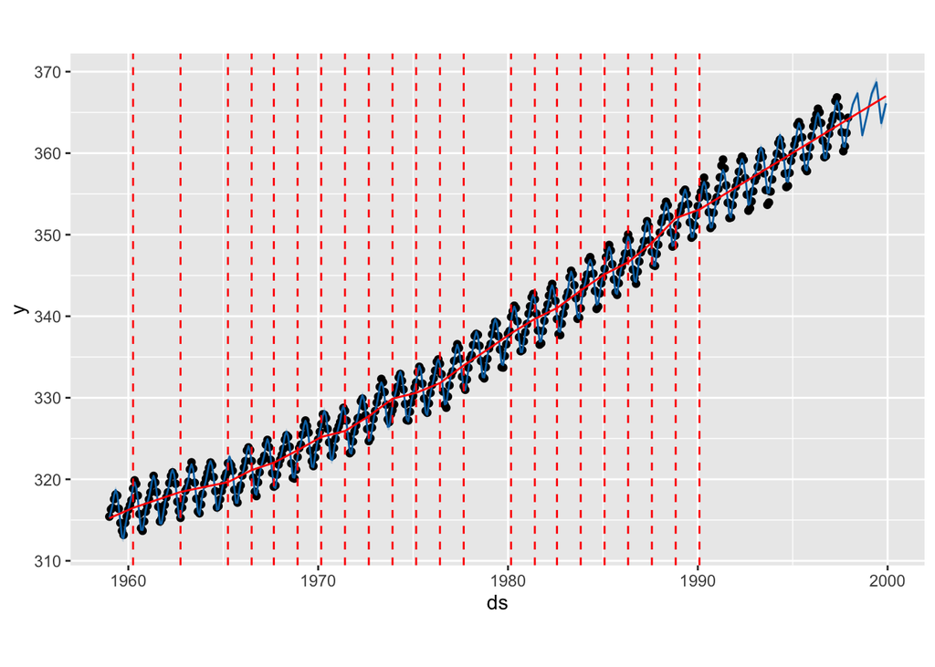

```r
plot(model, forecast) + add_changepoints_to_plot(model)
```

This plot conveys the points at which the rate of increase in CO2 levels changes significantly, indicated with the vertical red dashed lines. These may be because of natural disasters or the state of the economy, affecting production levels.

## Uncertainty in Seasonality

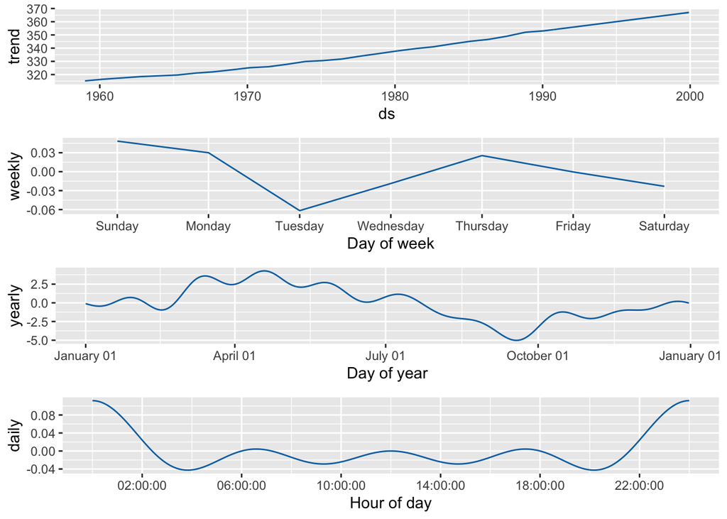

```r
prophet_plot_components(model, forecast)
```

The first plot conveys a long-term increasing trend in the CO2 levels from 1960 to 1999, indicating a steady rise in concentrations over the years and a positive correlation.

The third plot conveys yearly seasonality. From this we can conclude that there are cyclical annual changes in CO2 levels, which contains peaks and troughs at specific times of the year. It suggests a pattern of CO2 fluctuation throughout the year with certain periods consistently higher or lower than the average.